# Untitled

# Reading descriptions

We will analyse the variable Opis(read description of spot/window) which is a flag and define relationship between reading description and grades

```r
reading_time_grade_relation = data %>% group_by(opis) %>% summarise(avg_time_to_view = mean(czas_w_sek), avg_ocem = mean(na.omit(oceM)), avg_ocejp = mean(na.omit(oceJP)), avg_ocep = mean(na.omit(oceP)), id_counts = n_distinct(ID))
reading_time_grade_relation
```

```
## # A tibble: 2 × 6
##    opis avg_time_to_view avg_ocem avg_ocejp avg_ocep id_counts
##   <int>            <dbl>    <dbl>     <dbl>    <dbl>     <int>
## 1     1         66.97272 3.754325  3.916373 3.867021       108
## 2    NA         65.92228 3.504264  3.806505 3.811281       132
```

```r
## here we see that there is very slight difference between grades of students who read and whose who dont read description...may be because some students understand things by reading whereas others by observing in detail...
```

# zach attribute analysis:

4 types of zach are :1 - patrzenie; 2 - dotykanie, 3 - uzywanie, 4 - eksperymentowanie

```r
summary(observation_data$zach)
```

```
##    Min. 1st Qu.  Median    Mean 3rd Qu.    Max.    NA's
##   1.000   2.000   3.000   2.432   3.000   4.000     887
```

```r
zach_analysis = observation_data %>% group_by(zach) %>% summarise(avg_time_to_view = mean(czas_w_sek), id_counts = n_distinct(ID),  expotCount = n_distinct(ID))
zach_analysis <- zach_analysis[complete.cases(zach_analysis[, 'zach']),]

zach_analysis$zach <- as.character(zach_analysis$zach)
zach_analysis$zach[zach_analysis$zach == '1'] <- "patrzenie"
zach_analysis$zach[zach_analysis$zach == '2'] <- "dotykanie"
zach_analysis$zach[zach_analysis$zach == '3'] <- "uzywanie"
zach_analysis$zach[zach_analysis$zach == '4'] <- "eksperymentowanie"

summary(zach_analysis$avg_time_to_view)
```

```
##    Min. 1st Qu.  Median    Mean 3rd Qu.    Max.
##   34.12   36.16   49.16   58.96   71.96  103.40
```

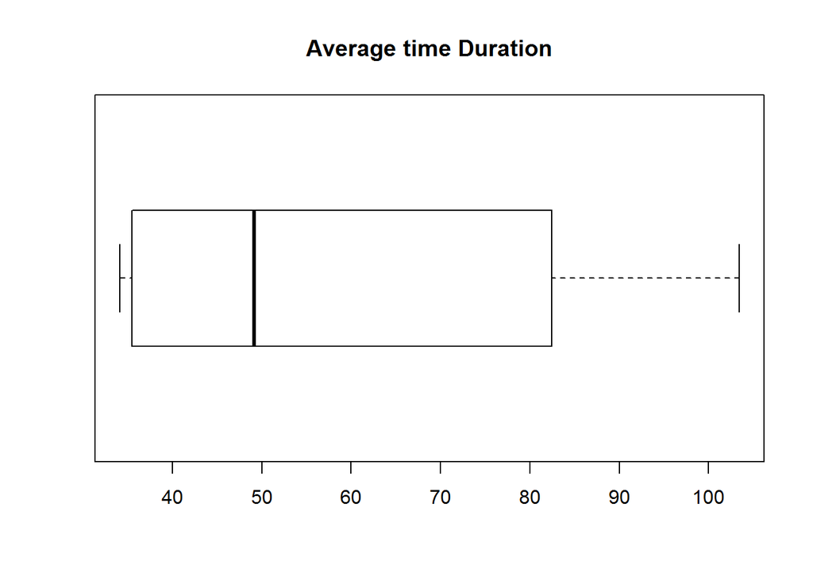

```r
boxplot(zach_analysis$avg_time_to_view, horizontal = TRUE, main="Average time Duration")
```

```r
summary(zach_analysis$id_counts)
```

```
##    Min. 1st Qu.  Median    Mean 3rd Qu.    Max.
##   110.0   125.0   130.5   125.8   131.2   132.0
```

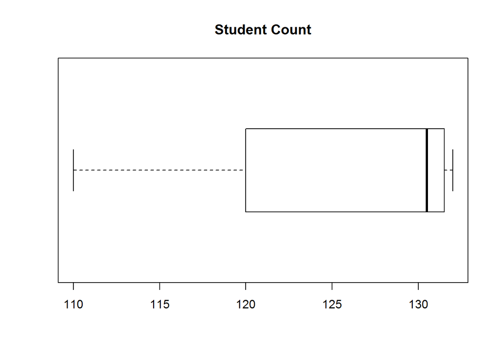

```r
boxplot(zach_analysis$id_counts, horizontal = TRUE, main="Student Count")
```

```r
summary(zach_analysis$expotCount)
```

```
##    Min. 1st Qu.  Median    Mean 3rd Qu.    Max.
##   110.0   125.0   130.5   125.8   131.2   132.0
```

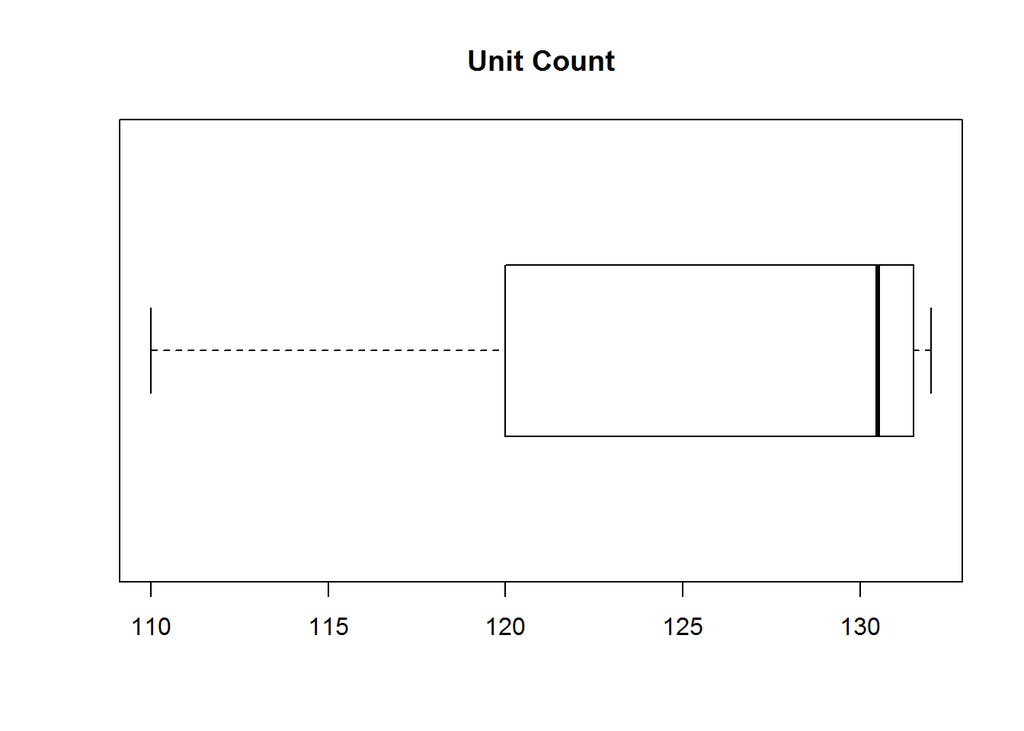

```r
boxplot(zach_analysis$expotCount, horizontal = TRUE, main="Unit Count")
```

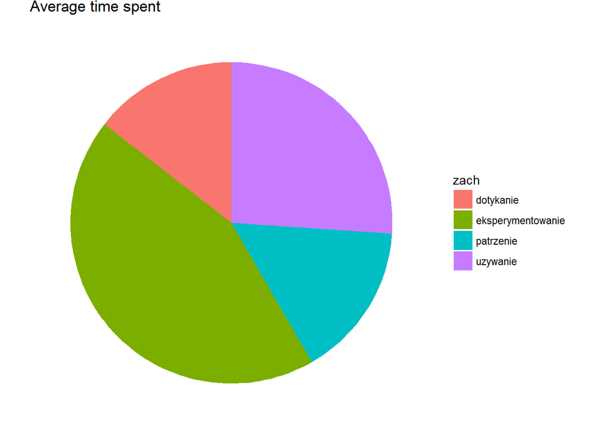

```r
ggplot(zach_analysis, aes(x="", y=avg_time_to_view, fill=zach)) +
geom_bar(width = 1, stat = "identity")+ coord_polar("y", start=0) +
  theme_void() +
    ggtitle("Average time spent")
```

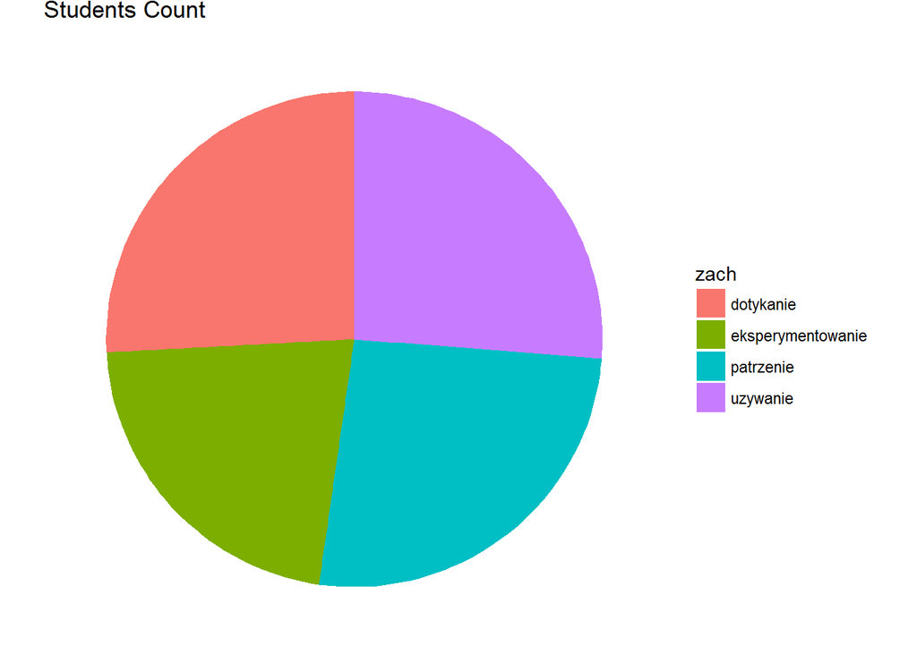

```r
ggplot(zach_analysis, aes(x="", y=id_counts, fill=zach)) +
geom_bar(width = 1, stat = "identity")+ coord_polar("y", start=0) +
  theme_void() +
    ggtitle("Students Count")
```

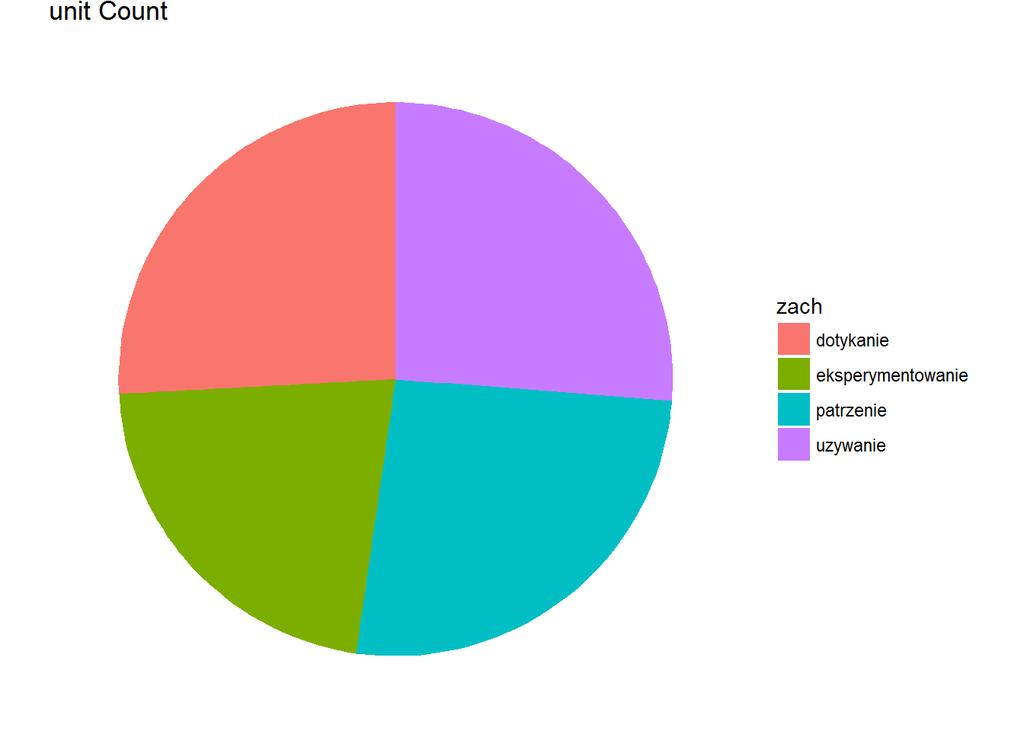

```r
ggplot(zach_analysis, aes(x="", y=expotCount, fill=zach)) +
geom_bar(width = 1, stat = "identity")+ coord_polar("y", start=0) +
  theme_void() +
    ggtitle("unit Count")
```

# Parents Analysis :

how grades are related to parent’s work status ( currently working or not)

Parentanalysis for mother

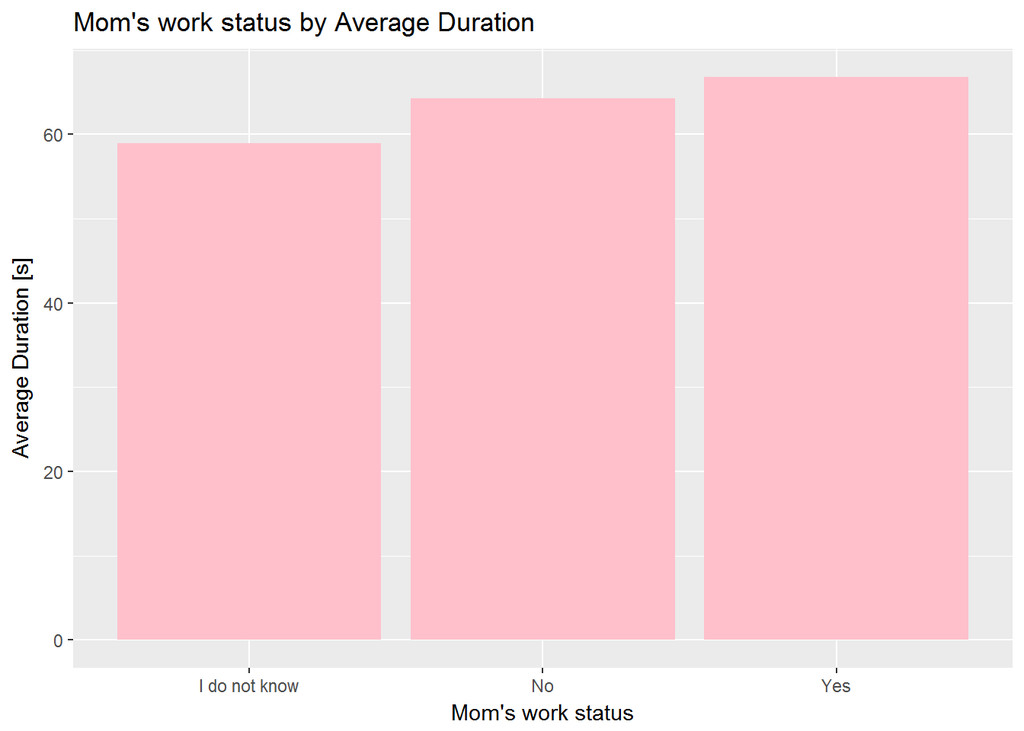

```r
workingMom = data %>% group_by(pracaM) %>% summarise(avg_time_to_view = mean(czas_w_sek), subject_1 = mean(na.omit(oceM)), subject_2 = mean(na.omit(oceJP)), subject_3 = mean(na.omit(oceP)))

workingMom <- workingMom[complete.cases(workingMom[, 'pracaM']),]

workingMom$pracaM <- as.character(workingMom$pracaM)
workingMom$pracaM[workingMom$pracaM == '1'] <- "Yes"
workingMom$pracaM[workingMom$pracaM == '2'] <- "No"
workingMom$pracaM[workingMom$pracaM == '3'] <- "I do not know"

ggplot(data=workingMom, aes(x=pracaM, y=avg_time_to_view)) +
    geom_bar(stat="identity", fill="pink") +
    ggtitle("Mom's work status by Average Duration")  +
    xlab("Mom's work status") +
    ylab("Average Duration [s]")
```

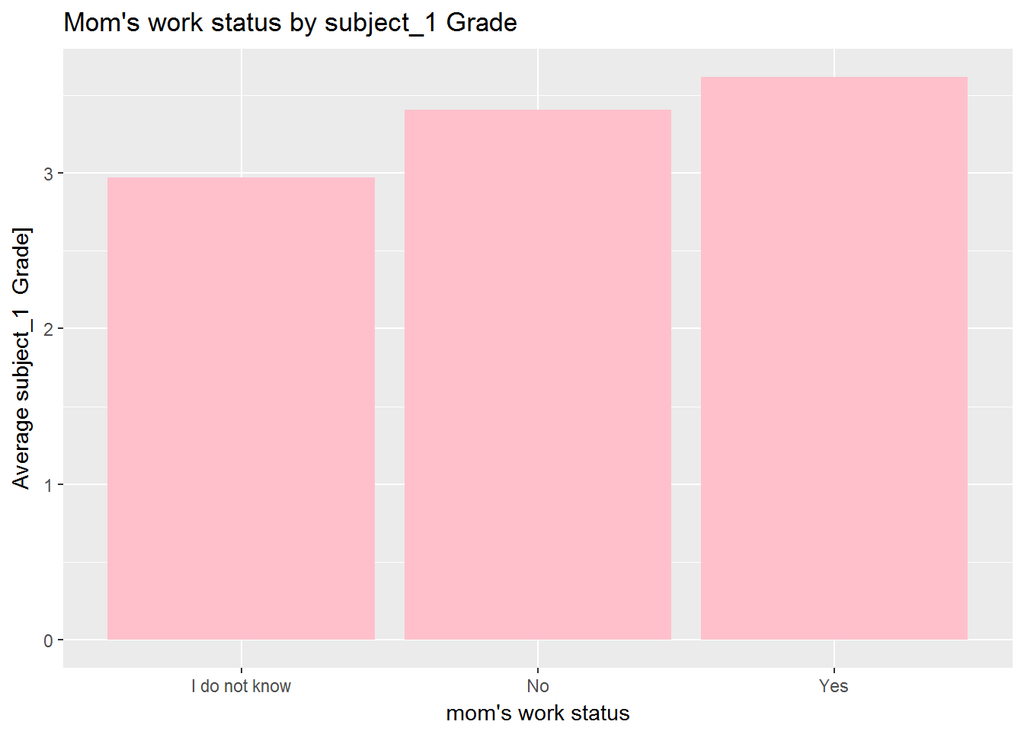

```r
ggplot(data=workingMom, aes(x=pracaM, y=subject_1)) +
    geom_bar(stat="identity", fill="pink") +
    ggtitle("Mom's work status by subject_1 Grade")  +
    xlab("mom's work status") +
    ylab("Average subject_1  Grade]")
```

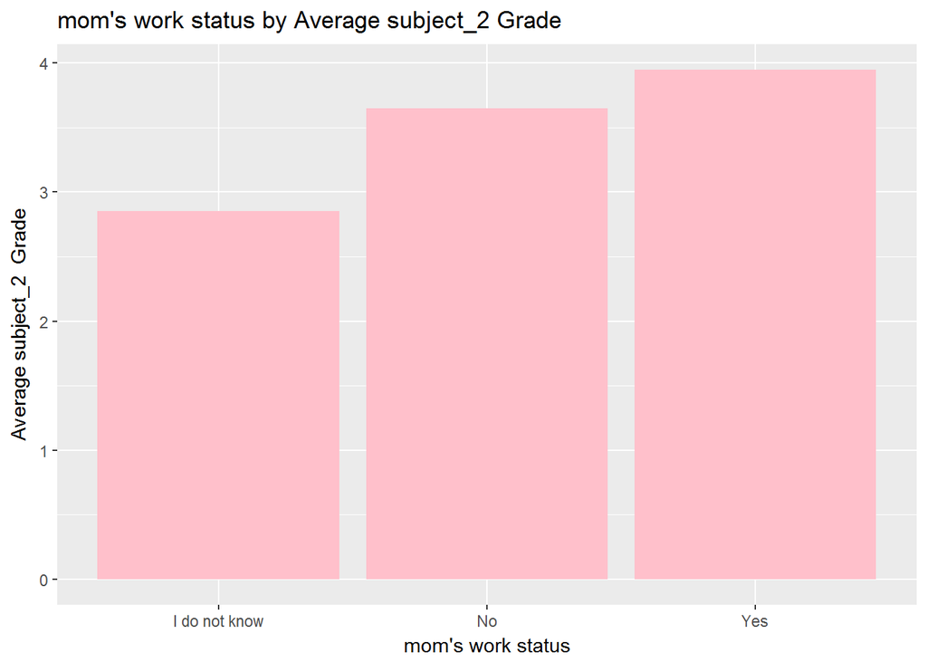

```r
ggplot(data=workingMom, aes(x=pracaM, y=subject_2)) +
    geom_bar(stat="identity", fill="pink") +
    ggtitle("mom's work status by Average subject_2 Grade")  +
    xlab("mom's work status") +
    ylab("Average subject_2  Grade")
```

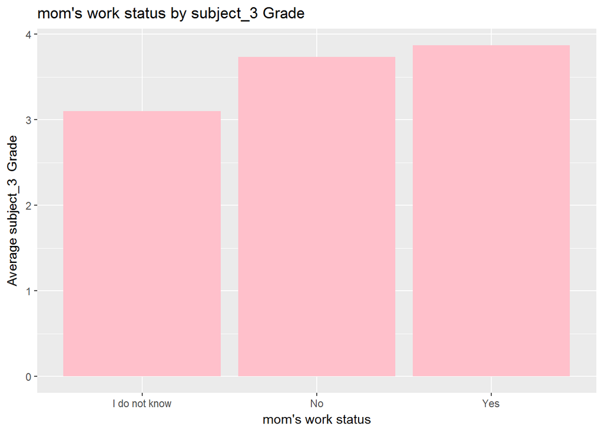

```r
ggplot(data=workingMom, aes(x=pracaM, y=subject_3)) +
    geom_bar(stat="identity", fill="pink") +
    ggtitle("mom's work status by subject_3 Grade")  +
    xlab("mom's work status") +
    ylab("Average subject_3  Grade")
```

so here we see that students with working mom are better performing(grades and longer view time) then the student who dont even know about there mom’s working status.conclusion is that working mom’s have better performing kids.